# lab01 - Relatório

,

01/25/2015

# Leitura de dados

```r
# Carregando os dados
library(openxlsx)
library(magrittr)
siglas <- read.xlsx('bd/pnud.xlsx', sheet=1)
municipios <- read.xlsx('bd/pnud.xlsx', sheet=2)
estados <- read.xlsx('bd/pnud.xlsx', sheet=3)

## Alternativas
# municipios <- read.csv('bd/pnud_municipios_csv.csv')
# municipios <- read.csv2('bd/pnud_municipios_csv2.csv')
# municipios <- read.table('bd/pnud_municipios_csv.csv', sep=',', dec='.')
# municipios <- read.table('bd/pnud_municipios_csv2.csv', sep=';', dec=',')
```

# Trabalhando com os dados dos estados

### Alguns testes com os dados

```r
dim(estados)         # dimensões (linhas e colunas)
head(estados, 10)    # primeiras linhas do banco de estados
tail(estados, 10)    # últimas seis linhas do banco de estados
names(estados)       # nomes das colunas dos estados
summary(estados)     # sumarizações dos estados
View(estados)        # mostra as primeiras 1000 linhas e 100 colunas
str(estados)         # mostra a estrutura do data.frame
```

## Algumas perguntas iniciais

### Quantas linhas temos na base de dados?

```r
nrow(estados)
```

```
## [1] 81
```

O número de linhas da base de dados é 81 linhas.

### Quantas colunas temos na base de dados?

```r
ncol(estados)
```

```
## [1] 235
```

### Na variável `ano`, quais são os diferentes anos?

```r
table(estados$ano)
```

```
##
## 1991 2000 2010
##   27   27   27
```

### Mostre a coluna com os nomes dos estados

```r
estados$ufn
```

```
##  [1] "Rondônia"            "Acre"                "Amazonas"
##  [4] "Roraima"             "Pará"                "Amapá"
##  [7] "Tocantins"           "Maranhão"            "Piauí"
## [10] "Ceará"               "Rio Grande do Norte" "Paraíba"
## [13] "Pernambuco"          "Alagoas"             "Sergipe"
## [16] "Bahia"               "Minas Gerais"        "Espírito Santo"
## [19] "Rio de Janeiro"      "São Paulo"           "Paraná"
## [22] "Santa Catarina"      "Rio Grande do Sul"   "Mato Grosso do Sul"
## [25] "Mato Grosso"         "Goiás"               "Distrito Federal"
## [28] "Rondônia"            "Acre"                "Amazonas"
## [31] "Roraima"             "Pará"                "Amapá"
## [34] "Tocantins"           "Maranhão"            "Piauí"
## [37] "Ceará"               "Rio Grande do Norte" "Paraíba"
## [40] "Pernambuco"          "Alagoas"             "Sergipe"
## [43] "Bahia"               "Minas Gerais"        "Espírito Santo"
## [46] "Rio de Janeiro"      "São Paulo"           "Paraná"
## [49] "Santa Catarina"      "Rio Grande do Sul"   "Mato Grosso do Sul"
## [52] "Mato Grosso"         "Goiás"               "Distrito Federal"
## [55] "Rondônia"            "Acre"                "Amazonas"
## [58] "Roraima"             "Pará"                "Amapá"
## [61] "Tocantins"           "Maranhão"            "Piauí"
## [64] "Ceará"               "Rio Grande do Norte" "Paraíba"
## [67] "Pernambuco"          "Alagoas"             "Sergipe"
## [70] "Bahia"               "Minas Gerais"        "Espírito Santo"
## [73] "Rio de Janeiro"      "São Paulo"           "Paraná"
## [76] "Santa Catarina"      "Rio Grande do Sul"   "Mato Grosso do Sul"
## [79] "Mato Grosso"         "Goiás"               "Distrito Federal"
```

### Ordene em ordem alfabética

```r
sort(estados$ufn)
```

```
##  [1] "Acre"                "Acre"                "Acre"
##  [4] "Alagoas"             "Alagoas"             "Alagoas"
##  [7] "Amapá"               "Amapá"               "Amapá"
## [10] "Amazonas"            "Amazonas"            "Amazonas"
## [13] "Bahia"               "Bahia"               "Bahia"
## [16] "Ceará"               "Ceará"               "Ceará"
## [19] "Distrito Federal"    "Distrito Federal"    "Distrito Federal"
## [22] "Espírito Santo"      "Espírito Santo"      "Espírito Santo"
## [25] "Goiás"               "Goiás"               "Goiás"
## [28] "Maranhão"            "Maranhão"            "Maranhão"
## [31] "Mato Grosso"         "Mato Grosso"         "Mato Grosso"
## [34] "Mato Grosso do Sul"  "Mato Grosso do Sul"  "Mato Grosso do Sul"
## [37] "Minas Gerais"        "Minas Gerais"        "Minas Gerais"
## [40] "Pará"                "Pará"                "Pará"
## [43] "Paraíba"             "Paraíba"             "Paraíba"
## [46] "Paraná"              "Paraná"              "Paraná"
## [49] "Pernambuco"          "Pernambuco"          "Pernambuco"
## [52] "Piauí"               "Piauí"               "Piauí"
## [55] "Rio de Janeiro"      "Rio de Janeiro"      "Rio de Janeiro"
## [58] "Rio Grande do Norte" "Rio Grande do Norte" "Rio Grande do Norte"
## [61] "Rio Grande do Sul"   "Rio Grande do Sul"   "Rio Grande do Sul"
## [64] "Rondônia"            "Rondônia"            "Rondônia"
## [67] "Roraima"             "Roraima"             "Roraima"
## [70] "Santa Catarina"      "Santa Catarina"      "Santa Catarina"
## [73] "São Paulo"           "São Paulo"           "São Paulo"
## [76] "Sergipe"             "Sergipe"             "Sergipe"
## [79] "Tocantins"           "Tocantins"           "Tocantins"
```

```r
## outro jeito
# estados$ufn[order(estados$ufn)]
```

### Agora mostre os nomes dos estados apenas uma vez cada

```r
unique(estados$ufn)
```

```
##  [1] "Rondônia"            "Acre"                "Amazonas"
##  [4] "Roraima"             "Pará"                "Amapá"
##  [7] "Tocantins"           "Maranhão"            "Piauí"
## [10] "Ceará"               "Rio Grande do Norte" "Paraíba"
## [13] "Pernambuco"          "Alagoas"             "Sergipe"
## [16] "Bahia"               "Minas Gerais"        "Espírito Santo"
## [19] "Rio de Janeiro"      "São Paulo"           "Paraná"
## [22] "Santa Catarina"      "Rio Grande do Sul"   "Mato Grosso do Sul"
## [25] "Mato Grosso"         "Goiás"               "Distrito Federal"
```

```r
## alternativas
# names(table(dados$ufn))
# dados$ufn[dados$ano==1991]
# ...
```

### selecione as variáveis `ano`, `ufn` e `idhm` e mostre apenas as 10 primeiras linhas

```r
estados[, c('ano', 'ufn', 'idhm')] %>% head(10)
```

```
##     ano       ufn  idhm
## 1  1991  Rondônia 0.407
## 2  1991      Acre 0.402
## 3  1991  Amazonas 0.430
## 4  1991   Roraima 0.459
## 5  1991      Pará 0.413
## 6  1991     Amapá 0.472
## 7  1991 Tocantins 0.369
## 8  1991  Maranhão 0.357
## 9  1991     Piauí 0.362
## 10 1991     Ceará 0.405
```

### Obtenha somente o ano de 2010

```r
estados[estados$ano == 2010, c('ano', 'ufn', 'idhm')]
```

```
##     ano                 ufn  idhm
## 55 2010            Rondônia 0.690
## 56 2010                Acre 0.663
## 57 2010            Amazonas 0.674
## 58 2010             Roraima 0.707
## 59 2010                Pará 0.646
## 60 2010               Amapá 0.708
## 61 2010           Tocantins 0.699
## 62 2010            Maranhão 0.639
## 63 2010               Piauí 0.646
## 64 2010               Ceará 0.682
## 65 2010 Rio Grande do Norte 0.684
## 66 2010             Paraíba 0.658
## 67 2010          Pernambuco 0.673
## 68 2010             Alagoas 0.631
## 69 2010             Sergipe 0.665
## 70 2010               Bahia 0.660
## 71 2010        Minas Gerais 0.731
## 72 2010      Espírito Santo 0.740
## 73 2010      Rio de Janeiro 0.761
## 74 2010           São Paulo 0.783
## 75 2010              Paraná 0.749
## 76 2010      Santa Catarina 0.774
## 77 2010   Rio Grande do Sul 0.746
## 78 2010  Mato Grosso do Sul 0.729
## 79 2010         Mato Grosso 0.725
## 80 2010               Goiás 0.735
## 81 2010    Distrito Federal 0.824
```

### Ordene a base de dados anterior pelo idhm em ordem crescente

```r
estados_subset <- estados[estados$ano == 2010, c('ano', 'ufn', 'idhm')]
estados_subset[order(estados_subset$idhm), ]
```

```
##     ano                 ufn  idhm
## 68 2010             Alagoas 0.631
## 62 2010            Maranhão 0.639
## 59 2010                Pará 0.646
## 63 2010               Piauí 0.646
## 66 2010             Paraíba 0.658
## 70 2010               Bahia 0.660
## 56 2010                Acre 0.663
## 69 2010             Sergipe 0.665
## 67 2010          Pernambuco 0.673
## 57 2010            Amazonas 0.674
## 64 2010               Ceará 0.682
## 65 2010 Rio Grande do Norte 0.684
## 55 2010            Rondônia 0.690
## 61 2010           Tocantins 0.699
## 58 2010             Roraima 0.707
## 60 2010               Amapá 0.708
## 79 2010         Mato Grosso 0.725
## 78 2010  Mato Grosso do Sul 0.729
## 71 2010        Minas Gerais 0.731
## 80 2010               Goiás 0.735
## 72 2010      Espírito Santo 0.740
## 77 2010   Rio Grande do Sul 0.746
## 75 2010              Paraná 0.749
## 73 2010      Rio de Janeiro 0.761
## 76 2010      Santa Catarina 0.774
## 74 2010           São Paulo 0.783
## 81 2010    Distrito Federal 0.824
```

### Agora em ordem decrescente

```r
estados_subset[order(estados_subset$idhm, decreasing = TRUE), ]
```

```
##     ano                 ufn  idhm
## 81 2010    Distrito Federal 0.824
## 74 2010           São Paulo 0.783
## 76 2010      Santa Catarina 0.774
## 73 2010      Rio de Janeiro 0.761
## 75 2010              Paraná 0.749
## 77 2010   Rio Grande do Sul 0.746
## 72 2010      Espírito Santo 0.740
## 80 2010               Goiás 0.735
## 71 2010        Minas Gerais 0.731
## 78 2010  Mato Grosso do Sul 0.729
## 79 2010         Mato Grosso 0.725
## 60 2010               Amapá 0.708
## 58 2010             Roraima 0.707
## 61 2010           Tocantins 0.699
## 55 2010            Rondônia 0.690
## 65 2010 Rio Grande do Norte 0.684
## 64 2010               Ceará 0.682
## 57 2010            Amazonas 0.674
## 67 2010          Pernambuco 0.673
## 69 2010             Sergipe 0.665
## 56 2010                Acre 0.663
## 70 2010               Bahia 0.660
## 66 2010             Paraíba 0.658
## 59 2010                Pará 0.646
## 63 2010               Piauí 0.646
## 62 2010            Maranhão 0.639
## 68 2010             Alagoas 0.631
```

### Calcule a renda per capita média dos estados em relação aos anos

```r
medias <- numeric(27)
estados_unique <- sort(unique(estados$ufn))
names(medias) <- estados_unique
for(i in seq_along(estados_unique)) {
  rdpc_subs <- estados[estados$ufn == estados_unique[i], 'rdpc']
  medias[i] <- mean(rdpc_subs)
}
medias
```

```
##                Acre             Alagoas               Amapá
##            389.2467            309.9433            467.3733
##            Amazonas               Bahia               Ceará
##            412.4167            351.1133            330.2233
##    Distrito Federal      Espírito Santo               Goiás
##           1276.8500            588.9933            597.6700
##            Maranhão         Mato Grosso  Mato Grosso do Sul
##            245.0267            580.1600            602.9600
##        Minas Gerais                Pará             Paraíba
##            557.4700            351.9133            323.5400
##              Paraná          Pernambuco               Piauí
##            656.0833            389.4800            279.5800
##      Rio de Janeiro Rio Grande do Norte   Rio Grande do Sul
##            824.7133            378.9200            724.9900
##            Rondônia             Roraima      Santa Catarina
##            480.9600            501.6700            709.1667
##           São Paulo             Sergipe           Tocantins
##            904.3600            365.9933            391.5367
```

```r
## mais facil
# tapply(estados$rdpc, estados$ufn, mean)
```

### Calcule a renda per capita média do Brasil em cada ano. Essa média faz sentido?

```r
tapply(estados$rdpc, estados$ano, mean)
```

```
##     1991     2000     2010
## 365.7848 491.9474 696.9737
```

Essa média não faz sentido pois a renda per capita é uma razão da renda total pela população. Idealmente deveríamos ter a população cada estado, e construir uma média ponderada.

### Calcule o valor correto da renda per capita do Brasil em cada ano

```r
## obs: a variável populacional utilizada no cálculo de rdpc é pop

anos_unique <- unique(estados$ano)
medias_ponderadas <- numeric(3)
names(medias_ponderadas) <- anos_unique
for(i in seq_along(anos_unique)) {
  d <- estados[estados$ano == anos_unique[i], c('rdpc', 'pop')]
  medias_ponderadas[i] <- sum(d$rdpc * d$pop) / sum(d$pop)
}
medias_ponderadas
```

```
##     1991     2000     2010
## 447.6130 592.4613 793.8724
```

```r
## jeito mais facil
# denominador <- tapply(estados$pop, estados$ano, sum)
# numerador <- tapply(estados$rdpc * estados$pop, estados$ano, sum)
# numerador / denominador
```

### Outliers em relação ao índice de GINI

OBS: O índice de GINI mede desigualdade social (quanto maior, pior)

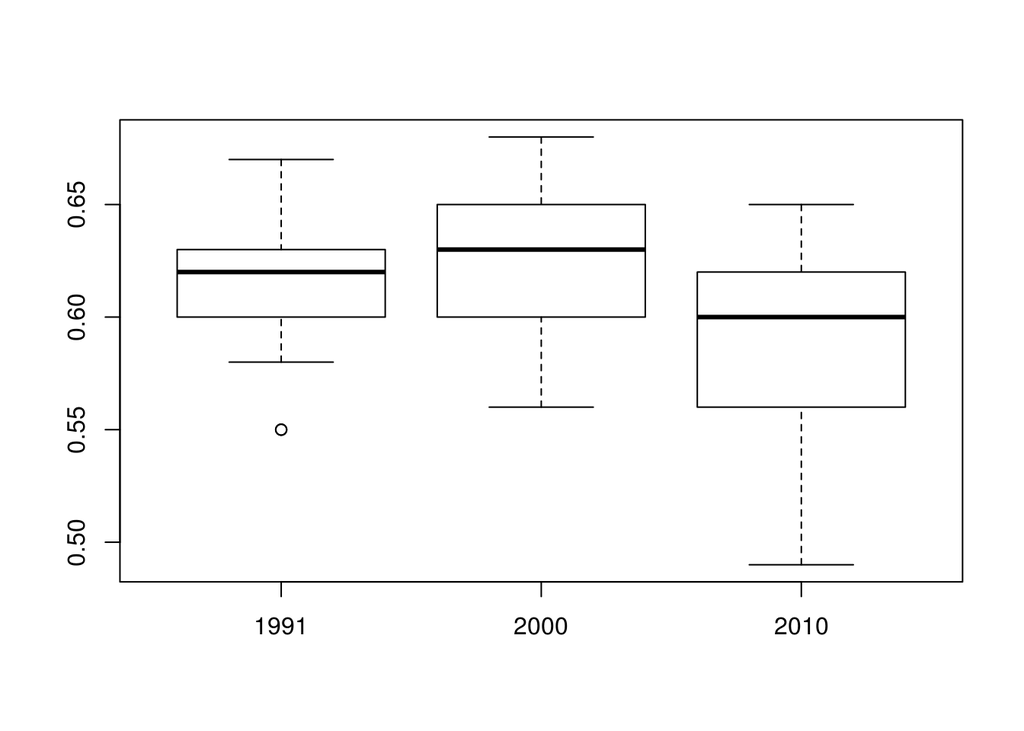

```r
boxplot(gini~ano, data=estados)
```

Dá para notar um outlier em 1991. Quem é?

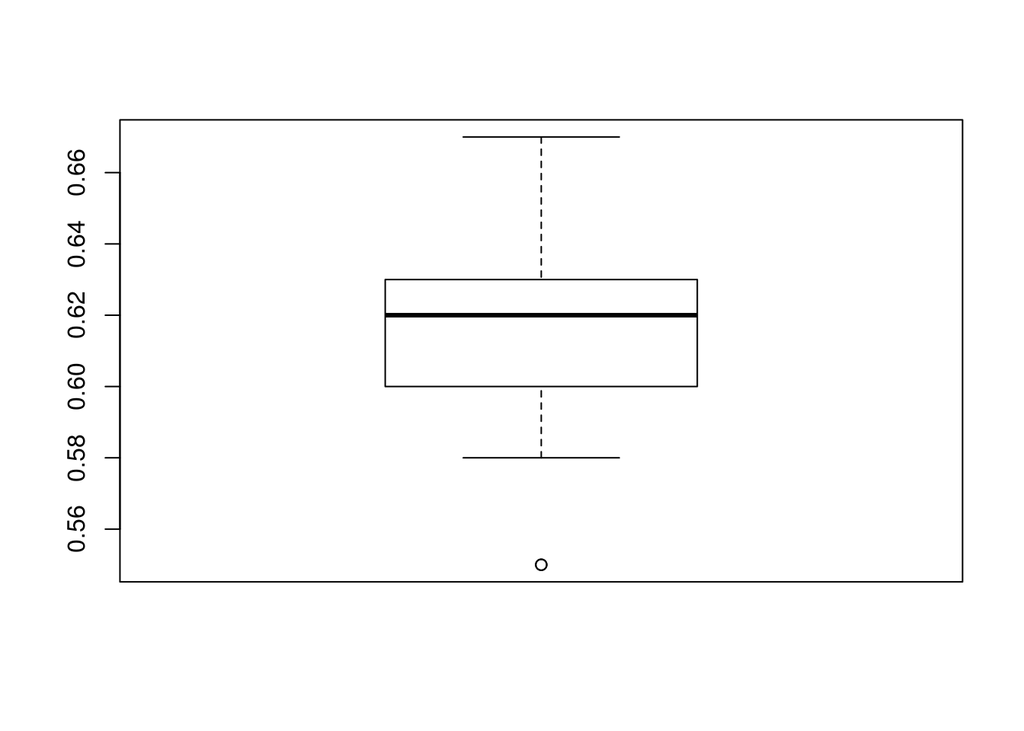

```r
boxp <- boxplot(gini~ano, data=estados[estados$ano==1991,])
```

```r
boxp$out
```

```
## [1] 0.55 0.55
```

```r
estados[estados$ano==1991 & estados$gini %in% boxp$out, 'ufn']
```

```
## [1] "São Paulo"      "Santa Catarina"
```

### O brasil está melhorando em relação ao IDH?

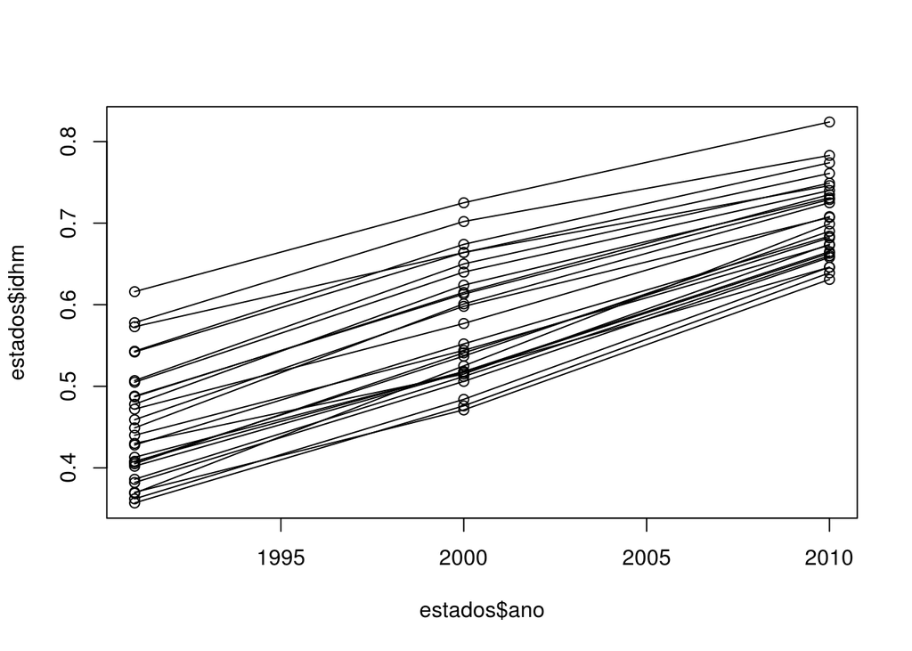

```r
estados_unique <- sort(unique(estados$ufn))
plot(estados$ano, estados$idhm)
for(i in seq_along(estados_unique)) {
  estado <- estados[estados$ufn==estados_unique[i], ]
  lines(estado$ano, estado$idhm)
}
```

Sim!

# Exercício do Laboratório

O arquivo contém 3 planilhas. Vamos utilizar a planilha *siglas*, que contém a definição das variáveis, e a planilha *municipios*, que contém as informações demográficas e socioeconômicas por município brasileiro.

## Questões iniciais

### Quais são os seis municípios com os maiores IDH municipais em 2010.

```r
# complete aqui
```

### Qual é a unidade federativa com menor expectativa de vida média, ponderada pela população dos municípios em 2000.

```r
# complete aqui
```

### Quais são os municípios *outliers* com relação ao índice de Gini em 1991 e em 2010.

```r
# complete aqui
```

## Mais questões:

### Visualize como está distribuída a população dos municípios no Brasil. Quantos municípios concentram 25% da população?

```r
# complete aqui
```

### Categorize a renda per capita e associe com a expectativa de vida.

```r
# complete aqui
```

### Você acha que a situação do Brasil está melhorando em relação à educação, renda e expectativa de vida? Justifique utlizando dados de pelo menos 3 variáveis.

```r
# complete aqui
```

### No nordeste o aumento de distribuição de renda foi maior do que no sudeste?

```r
# complete aqui
```

### Insira mais pelo menos 3 estudos que você ache interessante.

```r
# complete aqui
```